# lab3cp3

## Leitura dos dados

Nesta atividade utilizaremos um *dataset* com informações sobre as diferentes pós graduações brasileiras na área de informática e tecnologia. Encontramos as seguintes variáveis disponíveis para a análise:

```r
# leitura e filtragem dos dados
ppg = read_csv(file = "../data/capes-cacc.csv")
names(ppg)
```

```
##  [1] "Instituição"                "Programa"
##  [3] "Nível"                      "Sigla"
##  [5] "Tem doutorado"              "Docentes colaboradores"
##  [7] "Docentes permanentes"       "Docentes visitantes"
##  [9] "Resumos em conf"            "Resumos expandidos em conf"
## [11] "Artigos em conf"            "Dissertacoes"
## [13] "Teses"                      "periodicos_A1"
## [15] "periodicos_A2"              "periodicos_B1"
## [17] "periodicos_B2"              "periodicos_B3"
## [19] "periodicos_B4"              "periodicos_B5"
## [21] "periodicos_C"               "periodicos_NA"
## [23] "per_comaluno_A1"            "per_comaluno_A2"
## [25] "per_comaluno_B1"            "per_comaluno_B2"
## [27] "per_comaluno_B3"            "per_comaluno_B4"
## [29] "per_comaluno_B5"            "per_comaluno_C"
## [31] "per_comaluno_NA"
```

A partir dessas variáveis, vamos nos ater a estas: 1. Instituição: nome da instituição de ensino 2. Sigla: sigla da instituição de ensino 3. Nível: nível do curso de pós graduação da instituição de ensino perante a CAPES 4. qtd_artigo_por_prof: quantidade de artigos publicados em conferência, dividido pela soma de Docentes colaboradores com Docentes permanentes 5. trabalhos_de_conclusao: soma do número de Dissertações com o número de Teses 6. periodicos_excelencia: total de periódicos publicados com qualis A1 ou A2 ou B1 7. periodicos_outros: total de periódicos publicados com qualis diferente dos de excelência

```r
# substitui NA por 0
ppg[is.na(ppg)] = 0

# gerando novas variaveis a partir das existentes
ppg_plus = ppg %>%
  mutate(periodicos_excelencia = periodicos_A1 + periodicos_A2 + periodicos_B1) %>%
  mutate(periodicos_outros = periodicos_B2 + periodicos_B3 + periodicos_B4 + periodicos_B5 + periodicos_C + periodicos_NA) %>%
  mutate(qtd_artigo_por_prof = `Artigos em conf` / ( `Docentes colaboradores` + `Docentes permanentes` )) %>%
  mutate(trabalhos_de_conclusao = Dissertacoes + Teses)

ppg_filtered = ppg_plus %>%
  select(`Instituição`, `Sigla`, `Nível`, qtd_artigo_por_prof, trabalhos_de_conclusao, periodicos_excelencia, periodicos_outros)
```

# Visão geral dos dados

Para termos uma visão geral dos dados, vamos observar o histograma dos valores.

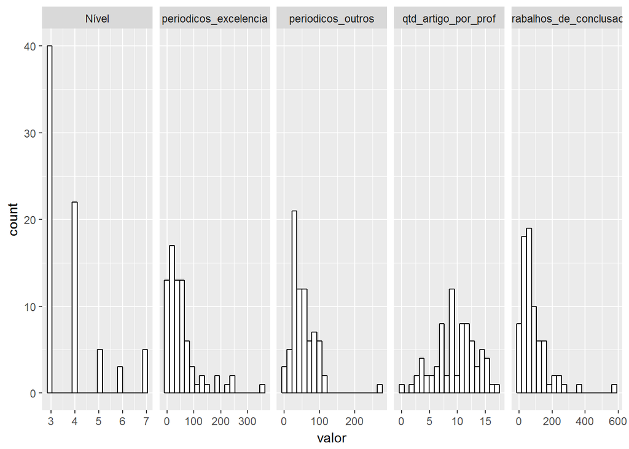

```r
# data overview
# summary(ppg_filtered)
# histogram
ppg_filtered %>%
    gather(key = "variavel", value = "valor", -`Instituição`, -`Sigla`) %>%
    ggplot(aes(x = valor)) +
    geom_histogram(fill = "white", color = "black", bins = 20) +
    facet_grid(. ~ variavel, scales = "free_x")
```

```r
# boxplot
boxplot_all = ppg_filtered %>%
    gather(key = "variavel", value = "valor", -`Instituição`, -`Sigla`) %>%
    ggplot(aes(x = "", y = valor)) +
    geom_boxplot() +
    facet_grid(. ~ variavel, scales = "free_x")
ggplotly(boxplot_all)
```

[interactive chart not shown]

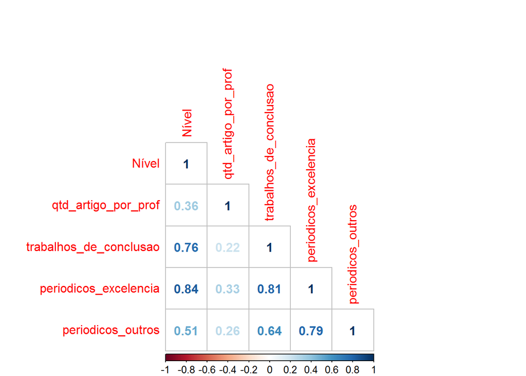

```r
# correlations
matrix_cor = cor(ppg_filtered %>% select(-`Instituição`, -Sigla))
corrplot(matrix_cor, method = "number", type = "lower")
```

Temos que a maioria da relações entre pares de variáveis possuem bastante correlação.

## Agrupamento

Vamos agora utilizar um método de agruapamento para ver se podemos separar os dados em diferentes grupos. Antes disso, devemos normalizar os dados e buscar identificar a quantidade de clusters em que devemos dividir nossos dados .

```r
# scale dos dados
ppg_scaled = ppg_filtered %>%
  mutate_at(vars(`Nível`:periodicos_outros), funs(as.numeric(scale(.))))
```

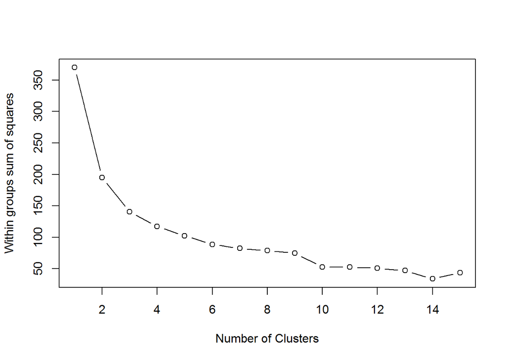

```r
# Determine number of clusters
wss <- (nrow(ppg_scaled[3:7])-1)*sum(apply(ppg_scaled[3:7],2,var))
for (i in 2:15) wss[i] <- sum(kmeans(ppg_scaled[3:7],
    centers=i)$withinss)
plot(1:15, wss, type="b", xlab="Number of Clusters",
  ylab="Within groups sum of squares")
```

Com o gráfico acima notamos que o erro acentua bastante a quando passamos de 3 para 2 clusters e pouco muda de 4 para 3. Então vamos usar o k-means para fazer o agrupamento passando como número de clusters requeridos, 3.

```r
# K-Means Cluster Analysis
fit <- kmeans(ppg_scaled[3:7], centers = 3, nstart = 20) # 3 cluster solution

# get cluster means
aggregate(ppg_scaled[3:7],by=list(fit$cluster),FUN=mean)
```

```
##   Group.1       Nível qtd_artigo_por_prof trabalhos_de_conclusao
## 1       1 -0.60029570          -0.7684151            -0.50533067
## 2       2  0.03033164           0.6862708            -0.02154852
## 3       3  2.42613872           0.4348975             2.23654298
##   periodicos_excelencia periodicos_outros
## 1           -0.52580566       -0.46264467
## 2           -0.03432901        0.07295452
## 3            2.37628122        1.66530243
```

```r
# append cluster assignment
ppg_scaled <- data.frame(ppg_scaled[3:7], fit$cluster)
```

```r
# plot parallel coordinates
ppg_scaled$.row <- rownames(ppg_scaled)
ppg_wide <- melt(ppg_scaled, id = c(".row", "fit.cluster") )

parallel_plot = ggplot(ppg_wide, aes(x = variable, y = value, group = .row, colour = fit.cluster)) +
    theme(axis.text.x = element_text(angle = 45, hjust = 0)) +
    geom_line(alpha = .2) +
    facet_wrap(~ fit.cluster)
ggplotly(parallel_plot)
```

[interactive chart not shown]

## Redução de dimensionalidade

Nesta seção iremos reduzir a dimensionalidade para facilitar a visualização. Iremos sair de cinco dimensões para duas, utilizando a técnica *principal component analysis - PCA*. Abaixo temos uma tabela a qual mostra a “equação” que representa cada dimensionalidade tendo as variáveis como fatores e um gráfico indicando a variância para diferentes quantidades de dimensões.

```r
ppg.pca <- prcomp(ppg_scaled[1:5],center = TRUE)
print(ppg.pca)
```

```
## Standard deviations:
## [1] 1.8239885 0.9330991 0.7131030 0.4683059 0.2730670
##
## Rotation:
##                               PC1          PC2         PC3         PC4
## Nível                  -0.4820431 -0.004908104  0.57063388 -0.44273938
## qtd_artigo_por_prof    -0.2437095 -0.955512590 -0.07351965  0.14554897
## trabalhos_de_conclusao -0.4850599  0.230114433  0.22798981  0.81224619
## periodicos_excelencia  -0.5255361  0.110678932 -0.03749812 -0.34074811
## periodicos_outros      -0.4435863  0.147543629 -0.78459312 -0.08333176
##                                 PC5
## Nível                   0.495952802
## qtd_artigo_por_prof    -0.031807788
## trabalhos_de_conclusao -0.006403201
## periodicos_excelencia  -0.770744179
## periodicos_outros       0.398662127
```

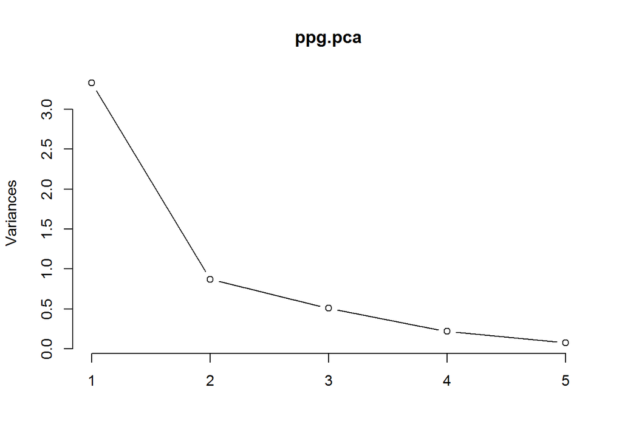

```r
plot(ppg.pca, type = "l")
```

A variância diminui muito a partir de duas dimensões mas não difere muito entre 2 e 3 dimensões, o que indica algo bom. Duas dimensões já explicam bastante dos dados.

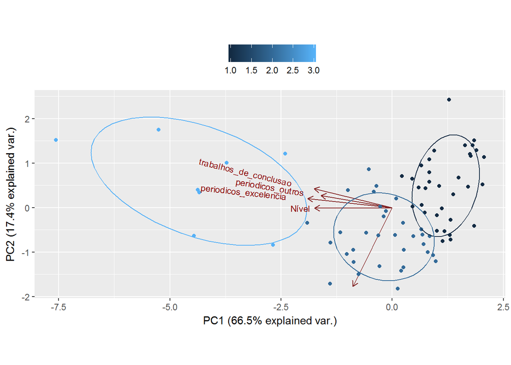

```r
library(devtools)
#install_github("ggbiplot", "vqv")

library(ggbiplot)
ppg.groups = ppg_scaled[, 6] #fit.cluster column
pca_plot <- ggbiplot(ppg.pca, obs.scale = 1, var.scale = 1,
              groups = ppg.groups, ellipse = TRUE,
              circle = FALSE) +
  scale_color_continuous(name = '') +
  theme(legend.direction = 'horizontal',
               legend.position = 'top')
print(pca_plot)
```

Por fim, temos nosso conjuntos de dados reduzido a duas dimensões e cada cor é referente a um dos grupos que foram formados anteriormente. Observamos que o Nível está intimamente relacionado com as variáveis que contam os periódicos e trabalhos de conclusão, estando eles quase alinhado com o eixo x. Examentente pela maioria das variáveis estarem “alinhadas” com o eixo x(PC 1), temos que só esse eixo já explica 66.5% dos nossos dados e a outra dimensão, PC 2, explica apenas 17.4%. Além disso, podemos dizer que a variável **quantidade de artigos por professor** não influencia muito a variável nível.